# Introduction To Bayesian Data Analysis

## Exercise

### **Question**

What is the probability of a passenger embarking in Queenstown?

N.B The ports are coded values.

- S = Southampton (England)
- C = Cherbourg (France)
- Q = Queenstown (Ireland) now known as Cobh

### **Python Answer**

```python
# Remove missing value from ports
ports_no_missing = titanic["embarked"].dropna()
(ports_no_missing == "Q").mean()
```

```
## 0.09410864575363427
```

Approximately 9.4%

### **R Answer**

```r
mean(titanic$embarked == "Q", na.rm = TRUE)
```

```
## [1] 0.09410865
```

Approximately 9.4 %

## 5.3 Joint Probability

### 5.3.1 Probability of A and B

So far only one probability has been covered; but often the possibility of A **AND** B needs to be explored.

For example the probability of a passenger being female is around 0.356. We can call this event A. This can be written as $P(A)$ = 0.356

The probability of a passenger surviving (survived == 1 ) is around 0.381. We can call this event B. This can be written as $P(B)$ = 0.381

We can also calculate the probability that the passenger is female **and** survived, this is called conjunction or intersection.

This is achieved by multiplying together the probability of A and the probability of B.

This is represented as $P(A \cap B)$ and is around 0.135 or 13.6%. This is lower than the probability of being female; as not all female passengers survived.

This can also be written as $P(A \cap B) = P(A) \times P(B)$ if independent.

### **Python**

```python
(titanic["sex"] == "female").mean() * (titanic["survived"] == 1).mean()
```

```
## 0.1357729736029369
```

Conjunction is commutative, e.g $P(A \cap B)$ = $P(A) \times P(B)$ is the same as $P(B \cap A)$ = $P(B) \times P(A)$

```python
(titanic["survived"] == 1).mean() * (titanic["sex"] == "female").mean()
```

```
## 0.1357729736029369
```

### **R**

```r
mean(titanic$sex == "female", na.rm = TRUE) * mean(titanic$survived == 1, na.rm = TRUE)
```

```
## [1] 0.1359805
```

Conjunction is commutative, e.g $P(A \cap B)$ = $P(A) \times P(B)$ is the same as $P(B \cap A)$ = $P(B) \times P(A)$

```r
mean(titanic$survived == 1, na.rm = TRUE) * mean(titanic$sex == "female", na.rm = TRUE)
```

```
## [1] 0.1359805
```

### 5.3.2 Probability of A or B

It’s also possible to calculate the probability of event A or B occurring by adding $P(A)$ and $P(B)$ together.

As our events are not mutually exclusive (e.g passengers can be female and survive or female and not survive) we also need to subtract the $P(A \cap B)$

The probability of a passenger being female or surviving is approx 0.602 or 60.2%. This can be written as $P(A \cup B)$ = 0.602

This can also be written as
$$P(A \cup B) =\ P(A) + P(B) - P(A \cap B)$$

### **Python**

```python
prob_female = (titanic["sex"] == "female").mean()
prob_survived = (titanic["survived"] == 1).mean()
prob_female_and_survived = prob_female * prob_survived


prob_female_or_survived = (prob_female + prob_survived) - prob_female_and_survived
prob_female_or_survived
```

```
## 0.6016316065497349
```

Again, this is commutative.

```python
prob_female_or_survived = (prob_survived + prob_female) - prob_female_and_survived
prob_female_or_survived
```

```
## 0.6016316065497349
```

### **R**

```r
prob_female <- mean(titanic$sex == "female", na.rm = TRUE)
prob_survived <- mean(titanic$survived == 1, na.rm = TRUE)
prob_female_and_survived <- prob_female * prob_survived

prob_female_or_survived <- (prob_female + prob_survived) - prob_female_and_survived
prob_female_or_survived
```

```
## [1] 0.6019874
```

Again this is commutative.

```r
prob_female_or_survived <- (prob_survived + prob_female) - prob_female_and_survived
prob_female_or_survived
```

```
## [1] 0.6019874
```

## 5.4 Conditional Probability

It’s also important to be able to calculate probability based on a condition.

For example if a random female passenger is picked; what’s the probability they survived.

A.K.A what is the probability that a passenger is survived, given that they are female?

We can find this by dividing the probability of A and B occurring by the probability of A occurring. Using notation this looks like this.
$$P(B|A) = \frac{P(A\cap B)}{P(A)}$$

Alternatively using our example

$$Probaility\ of\ survived\ given\ female = \frac{Probability\ female \ and \ survived}{Probability\ female}$$

### **Python**

```python
probability_female = (titanic["sex"] == "female").mean()
probability_survived = (titanic["survived"] == 1).mean()
probability_female_survived = probability_survived * probability_female


prob_survived_given_f = probability_female_survived / probability_female

prob_survived_given_f
```

```
## 0.3816793893129771
```

### **R**

```r
probability_female <- mean(titanic$sex == "female", na.rm = TRUE)
probability_survived <- mean(titanic$survived == 1, na.rm = TRUE)
probability_female_survived <- probability_survived * probability_female

prob_survived_given_f <- probability_female_survived / probability_female

prob_survived_given_f
```

```
## [1] 0.381971
```

This is **not** commutative;

### **Python**

```python
probability_female = (titanic["sex"] == "female").mean()
probability_survived = (titanic["survived"] == 1).mean()
probability_female_survived = probability_survived * probability_female


prob_f_given_survived = probability_female_survived / probability_survived

prob_f_given_survived
```

```
## 0.35572519083969467
```

### **R**

```r
probability_female <- mean(titanic$sex == "female")
probability_survived = mean(titanic$survived == 1)
probability_female_survived = probability_survived * probability_female

prob_survived_given_f <- probability_female_survived / probability_female

prob_survived_given_f
```

```
## [1] NA
```

This is also known as Bayes’ Theorem

## 5.5 The Law of Total Probability

In addition to the three theorems talked about above it’s also important to know the law of total probability.

$$P(A) = P(B_1\ and\ A)\ +\ P(B_2\ and\ A)$$

Essentially the probability if A is the sum of two possibilities. Either $B_1$ and $A$ are true, or $B_2$ and $A$ are true. This applies if $B_1$ and $B_2$ are mutually exclusive (only one can be true) and collectively exhaustive (one must be true)

Let’s return to the probability that a respondent survived.

### **Python**

```python
(titanic["survived"] == 1).mean()
```

```
## 0.3816793893129771
```

### **R**

```r
mean(titanic$survived == 1, na.rm = TRUE)
```

```
## [1] 0.381971
```

Now let’s check we get the same overall probability if we calculate male and female survivors independently.

### **Python**

```python
female_survived = (titanic["sex"] == "female").mean() * (titanic["survived"] == 1).mean()
male_survived = (titanic["sex"] == "male").mean() * (titanic["survived"] == 1).mean()

female_survived + male_survived
```

```
## 0.38138803100052443
```

### **R**

```r
female_survived <- mean(titanic$sex == "female", na.rm = TRUE) * mean(titanic$survived == 1, na.rm = TRUE)
male_survived <- mean(titanic$sex == "male", na.rm = TRUE) * mean(titanic$survived == 1, na.rm = TRUE)

female_survived + male_survived
```

```
## [1] 0.381971
```

There are only two given values for the sex of the passenger in this dataset; they are mutually exclusive and collectively exhaustive.

The law of total probability could also be written as

$$P(A) = P(B_1)P(A|B_1)+P(B_2)P(A|B_2)$$

### **Python**

```python
probability_male = (titanic["sex"] == "male").mean()
probability_female = (titanic["sex"] == "female").mean()
probability_survived = (titanic["survived"] == 1).mean()
probability_female_given_survived =  (probability_female * probability_survived) / probability_female
probability_male_given_survived =  (probability_male * probability_survived) / probability_male

(probability_male * probability_male_given_survived) + (probability_female * probability_female_given_survived)
#     P(B1)            P(A|B1)                       +     P(B2)                 P(A|B2)
```

```
## 0.38138803100052443
```

### **R**

```r
probability_male <- mean(titanic$sex == "male", na.rm = TRUE)
probability_female <- mean(titanic$sex == "female", na.rm = TRUE)
probability_survived <- mean(titanic$survived == 1, na.rm = TRUE)
probability_female_given_survived <-  (probability_female * probability_survived) / probability_female
probability_male_given_survived <-  (probability_male * probability_survived) / probability_male

(probability_male * probability_male_given_survived) + (probability_female * probability_female_given_survived)
```

```
## [1] 0.381971
```

```r
#     P(B1)            P(A|B1)                       +     P(B2)                 P(A|B2)
```

For more than two conditions writing the law of total probability as a summation is more concise

$$P(A) = \sum\limits_{i}P(B_i)P(A|B_i)$$

Which remains true as long as the conditions $B_i$ are mutually exclusive and collectively exhaustive.

# 6 Bayes’ Theorem

Bayes’ theorem is a principled way of calculating a conditional probability without the joint probability. We often don’t have access to the denominator (e.g $P(B)$) directly; and it can be calculated in an alternative way such as:

Which gives the formulation of Bayes’ Theorem that can be used to generate the alternate calculation of $P(B)$:

## 6.1 Example of Bayes Theorem

A classic example is an urn problem.

Two identical urns exist. Urn 1 contains 30 red marbles and 10 blue marbles. Urn 2 contains 20 red marbles and 20 blue marbles.

If one urn is chosen at random and 1 marble (selected without looking) chosen from that bowl. If the marble is red what is the probability that it came from urn 1?

This can be written as $P(U_1|R)$ or $P(urn\ one\ given \ red\ marble)$

From the statement we know

- The conditional probability of getting a red marble if we choose from bowl 1 $P(R|U_1)$
- The conditional probability of getting a red marble if we choose from bowl 2 $P(R|U_2)$

Bayes’ theorem shows the link

$$P(V_1|R) = \frac{p(V_1)P(R|V_1)}{P(R)}$$

$$P(V_1|R) = \frac{0.5 * 0.75}{0.625}$$

$$P(V_1|R) = \frac{0.375}{0.625}$$

$$P(V_1|R) = 0.6$$

## 6.2 Diachronic Bayes

Bayes’ rule is a recipe for turning around a conditional probability to learn about the thing we’re interested in. It’s possible to update the probability of a hypothesis (H) given some data (D) - the theorem can be re-written as:

$$P(H|D) = \frac{P(H) P(D|H)}{P(D)}$$

When written like this:

- $P(H)$ is the probability of the hypothesis before we consider the data - called the prior probability, often referred to as just **prior**.
- $P(H|D)$ is the probability of the hypothesis given the data; and is called the posterior.
- $P(D|H)$ is the probability of the data under the hypothesis and is called the likelihood.
- $P(D)$ is the total probability of the data under any hypothesis

Probability of having Zombie Virus is $P(Infected)$ = 0.000001

The Zombie test has no false negatives $P(Test Positive|Infected)$ = 1

But there are some false positives $P(Test Positive|Uninfected)$ = 0.001

Applying that into Bayes’ Rule

$$P(Infected|Test\ Positive) = \frac{P(Infected) P(Test\ Positive|Infected)}{P(Test\ Positive)}$$

Or to break it down further:

$$P(Test\ Positive) = P(Test\ Positive\ |\ Infected) * P(Infected) + P(Test\ Positive\ |\ Uninfected) * P(Uninfected)$$

To work out the probability of being uninfected we know $P(Uninfected) = 1 - P(Infected)$

So the previous statement can be re-arranged as

$$P(Test\ Positive\ |\ Infected) * P(Infected) + P(Test\ Positive\ |\ Uninfected) * (1- P(Infected))$$

$$P(Infected|Test\ Positive) = \frac{P(Infected) P(Test\ Positive|Infected)}{P(Test\ Positive)}$$

# 7 The Monty Hall Problem

“Let’s make a Deal” was an American TV show, starting in 1963 and was created and produced by Stefan Hatos and Monty Hall. Monty Hall served as the host for nearly 30 years.

The final game of each episode presented the winner with 3 doors (A, B and C). One door has the grand prize (such as a car) and the other two doors have lesser prizes. In the “Monty Hall Problem”, a probability puzzle loosely based on the game show the prizes are usually represented by a sports car with goats behind the other doors.

The contestant knows that there are 2 goats and 1 car but does not know what is behind which door. The host (Monty) knows what is behind each door.

The contestant chooses door A; before opening door A Monty opens door B revealing a Goat.

He now asks if the contestant would like to switch doors. Should the contestant switch doors?

[figure not shown]

Image Sources:  
[XKCD - Monty Hall](https://xkcd.com/1282/)

In this segment some of the terminology will be introduced such as “Posteriors”, “Priors” and “Likelihood” - these are explained in more detail in the next segment called “Components of Bayesian Models”.

## 7.1 Posteriors

If the contestant picks door A and Monty opens Door B. Monty will never open a door showing the car; so wouldn’t open door C if the car was behind it so we only need to calculate two posteriors.

1. $P(Door\ A|Opens\ B)$ The probability that A is correct if Monty opens B
2. $P(Door\ C|Opens\ B)$ The probability that C is correct if Monty opens B

## 7.2 Priors

The probability of any door being correct before a door is chosen is 1/3. Prizes are randomly arranged and we have no other information so the prior $P(A)$ of any door being correct is 1/3.

## 7.3 Likelihood

If the car is actually behind door A Monty is free to open either B or C so the probability of opening either is 1/2 (50%)

If the car is behind door C then Monty can only open door B. Monty can’t open door A as the contestant selected it; and can’t open door C as that has the car behind it.

$P(Opens\ B| Door\ A)$ is 0.5

$P(Opens\ B| Door\ C)$ is 1.0

## 7.4 Completing the formula

$$P(A|B) = \frac{P(B|A) \times P(A)} {P(B)}$$

**Numerator**

$P(Opens\ B|Door\ A) \times P(A)$ is 1/2 x 1/3 = 1/6

$P(Opens\ B|Door\ C) \times P(A)$ is 1/3 x 1 = 1/3

**Normalising Constant: P(B)**

As our analysed events cover all possible options and do not overlap the sum of the numerators can be used.

$P(B)$ = 1/6 + 1/3

$P(B)$ = 1/2

With these we can complete our formula.

$P(Door\ A| Opens\ B)$ = $\frac{1/6}{1/2}$

$P(Door\ A| Opens\ B)$ = 1/3

$P(Door\ C| Opens\ B)$ = $\frac{1/3}{1/2}$

$P(Door\ C| Opens\ B)$ = 2/3

**There is a higher probability of winning if the contestant changes doors after Monty has opened a door.**

# 8 Components of Bayesian Models

In this section the components of a Bayesian Model will be explored in more detail.

To illustrate these an example of estimating global surface water will be used. To estimate how much of the earth’s surface is covered in water an experiment is designed. A hand held globe is tossed in to the air, and when caught the presence of either land (L) or water (W) under the right index finger is recorded.

This experiment is repeated to generate the data; a sequence of observations.

`"W", "L", "W", "W", "W", "L", "W", "L", "W"`

McElreath **(Statistical Rethinking 2.2)** suggests that simple Bayesian Model Design benefits from three steps:

- *Data Story* - Motivate the model by narrating how the data may arise
  - Describe aspects of the underlying reality and the sampling process
  - Translate this description into a formal probability model
  - Acts as a framework for interpretation; but is still a story
  - Helps to highlight additional questions that must be answered (hypotheses are frequently vague)
- *Update* - Educate the model by feeding it data
  - Bayesian models begin with a set of plausibilities assigned to each possibility (the Prior)
  - Update those plausibilities based on the data to give **posterior** plausibility
- *Evaluate* - Is the model accurate or does it need to be changed.
  - Certainty is no guarantee that the model is accurate or good
  - Models should be supervised and critiqued
  - Check the model’s adequacy for the purpose or in light of new information.

## 8.1 Data Story

A data story attempts to explain how the data came to be. This can be either a descriptive or a causal explanation. Descriptive accounts specify associations that can help predict outcomes of interest and causal accounts explain how a process produces a given pattern.

A data story should be sufficiently complete to be able to generate new data. This is achieved by trying to explain how each piece of data is created as a result of the underlying reality and the sampling process.

## 8.2 Exercise

### **Question**

What is the data story for the globe tossing example?

### **Answer**

The data story is the sample process we stated earlier. “A globe is tossed in to the air and on catching if the area under the right index finger is land, ‘L’ is recorded. If the area is water ‘W’ is recorded.”

1. The true proportion of water covering the Earth is $p$
2. A single toss of the globe has the probability $p$ of producing water (‘W’) observations and a probability of 1-$p$ of producing land.
3. Each toss is an independent trial; previous tosses do not influence future ones.

## 8.3 Baysian Updating

A Bayesian model begins with one set of plausibilities assigned to each possible result - these are the prior plausibilities. These values are updated in light of data to produce our posterior plausibilities - though a process called Bayesian Updating.

The data helps to determine the plausibility of each possible proportion. The model starts with the given plausibility (a prior) assigned to every possible proportion of water (from 0% to 100%) and then updates these in line with the data seen to derive the posterior prior.

Before the globe is thrown for the first time it could be assumed that every proportion of water had the same plausibility. The first data point is “W” and we use this information to update the plausibility of each possible proportion. The plausibility for a 0% coverage of water is now 0; as some water has been observed if is now effectively impossible to have a 0 proportion of water. As no land has been observed the plausibility of higher proportions of water than land increases. With more observations the plausibility of each value in $p$ is revised; when a “W” is observed this makes higher values of P more plausible, when an L is observed it makes lower values of P more plausible.

In reality data is often presented to a computer all at once rather than the iterative process described above.

## 8.4 Evaluation

As the amount of data increases our model will become increasingly sure of the proportion of water. This happens even if the model is misleading because our estimates are conditional based on our model. Effectively given a specific model we can be sure that plausible values are within a narrow range.

For example a different model globe may have different results; is the globe used accurate or is there some loss in quality as it is scaled down?

> “There is no approach to inference that provides universal guarantees. No branch of applied mathematics has unfettered access to reality, because math is not discovered, like the proton. Instead it is invented, like the shovel”

> - Richard McElreath, *ibid.*

## 8.5 Likelihood

The likelihood function is a mathematical formula that calculates the plausibility of the data seen.

With the globe tossing example a binomial likelihood function could be used to derive a likelihood of the data occurring subject to different values of $p$. This works with binary data, such as success or failure and in the model we used Water or Land.

As a reminder our data was

`"W", "L", "W", "W", "W", "L", "W", "L", "W"`

The binomial distribution is given as $B(n,p)$ where $n$ is the number of trials and $p$ is the probability of success.

From this we can derive the probability of seeing $k$ successes, by getting the probability mass function for a given value of $k$.

The likelihood of the proportion of water on Earth being 0.5, given 9 trials and 6 successes (e.g getting W 6 times from 9 tosses).

### **Python**

```python
binom.pmf(k=6, n=9, p=0.5)
```

```
## 0.16406250000000006
```

### **R**

```r
dbinom(x = 6, size = 9, prob = 0.5)
```

```
## [1] 0.1640625
```

This value is the relative number of ways of getting six “W” values when you do nine trials and $p$ is equal to 0.5.

Changing $p$ gives a different likelihood.

### **Python**

```python
binom.pmf(k=6, n=9, p=0.7)
```

```
## 0.2668279319999999
```

### **R**

```r
dbinom(x = 6, size = 9, prob = 0.7)
```

```
## [1] 0.2668279
```

### **Python**

```python
binom.pmf(k=6,n=9,p=0.3)
```

```
## 0.021003947999999967
```

### **R**

```r
dbinom(x = 6, size = 9, prob = 0.3)
```

```
## [1] 0.02100395
```

| P | Ways |
| --- | --- |
| 0.3 | 0.02100395 |
| 0.5 | 0.1640625 |
| 0.7 | 0.26682793 |

There are not that many ways of getting 6 waters from 9 trials if $p$ is 0.3 so it’s quite a bit less plausible a value for the Earth’s surface than 0.5 or 0.7.

You may find it useful to read more about conuuancy and Beta Priors; there are several useful articles linked in the [Wikipedia Article on Conugate Prior](https://en.wikipedia.org/wiki/Conjugate_prior)

## 8.6 Paramaters

Above we specified our parameters in terms of the binomial likelihood

- $p$ - The probability of success - e.g the probability of observing water
- $n$ - The number of trials, a.k.a the sample size
- $k$ - The number of successes, e.g the number of “W” values observed.

In the globe testing example both $n$ and $k$ are known data, leaving $p$ as our unknown. We want to know what the most plausible value of $p$ is given our data.

In other contexts it may be needed to estimate different parameters of our model; of it may have many more parameters than a simple binomial likelihood function.

## 8.7 Priors

Every estimated parameter needs a prior. This is an initial assignment of plausibility for each possible value of a parameter.

Priors can be useful in constraining parameters to reasonable ranges or expressing any knowledge we have about the likely value of the parameter before any data is captured. In the globe tossing example prior knowledge says it is extremely unlikely that the earth has 0% water ($p = 0$) or 100% water ($p = 1$), and that values nearer $p = 0.5$ are more plausible than the extremes.

As priors are assumptions it is reasonable to try different priors to test the sensitivity of the model.

## 8.8 Posteriors

After the likelihood function, parameters and priors are known the Bayesian Model can be estimated. The resulting estimates are the relative plausibility of the different parameter values; conditional on the data seen. These are known as the **posterior distribution**

The posterior can be thought of as
$$Posterior = \frac{Likelihood\ x\ Prior}{Total\ Likelihood}$$

Where $Total\ Likelihood$ standardises the posterior ensuring the area under the curve is 1.

# 9 Aproximate Bayesian Compuation

## 9.1 Grid Aproximation

Grid approximation is often not a practical tool to use as it scales very poorly as the number of parameters increases; however it is useful to examine it as it requires an understanding of the nature of Bayesian updating.

For problems like the globe toss example a grid approximation is reasonable as a single parameter is being estimated.

The stages of a grid approximation:

1. Define a range of values to look at (the grid)
2. Calculate the value of the prior at each parameter value of the grid
3. Compute the likelihood at each parameter value
4. Compute the unstandardised posterior at each parameter, by multiplying the prior by the likelihood
5. Standardise the posterior by diving each value by the sum of all unstandardised values.

## Define a Grid

The larger the number of points on the grid the higher the precision of the estimates. More points will give a finer grained posterior.

### **Python**

```python
# define a grid for the posterior
p_grid = np.linspace(start=0, stop=1, num=20)
p_grid
```

```
## array([0.        , 0.05263158, 0.10526316, 0.15789474, 0.21052632,
##        0.26315789, 0.31578947, 0.36842105, 0.42105263, 0.47368421,
##        0.52631579, 0.57894737, 0.63157895, 0.68421053, 0.73684211,
##        0.78947368, 0.84210526, 0.89473684, 0.94736842, 1.        ])
```

### **R**

```r
p_grid <- seq(from = 0, to = 1, length.out = 20 ) # define grid
p_grid
```

```
##  [1] 0.00000000 0.05263158 0.10526316 0.15789474 0.21052632 0.26315789
##  [7] 0.31578947 0.36842105 0.42105263 0.47368421 0.52631579 0.57894737
## [13] 0.63157895 0.68421053 0.73684211 0.78947368 0.84210526 0.89473684
## [19] 0.94736842 1.00000000
```

## Define the Prior

The prior is a constant value of 1.

### **Python**

```python
prior = np.repeat(1, repeats=20)
prior
```

```
## array([1, 1, 1, 1, 1, 1, 1, 1, 1, 1, 1, 1, 1, 1, 1, 1, 1, 1, 1, 1])
```

### **R**

```r
prior <- rep(1, times = 20)
prior
```

```
##  [1] 1 1 1 1 1 1 1 1 1 1 1 1 1 1 1 1 1 1 1 1
```

## Calculate the Likelihood

The binomial function takes the grid values of p here rather than a single value like was used previously.

### **Python**

```python
likelihood = binom.pmf(k=6, n=9, p=p_grid)
likelihood
```

```
## array([0.00000000e+00, 1.51814898e-06, 8.18509295e-05, 7.77292279e-04,
##        3.59857537e-03, 1.11609461e-02, 2.66829865e-02, 5.29210991e-02,
##        9.08269760e-02, 1.38341326e-01, 1.89768623e-01, 2.36114658e-01,
##        2.66611252e-01, 2.71400562e-01, 2.45005089e-01, 1.89768623e-01,
##        1.17918118e-01, 5.02667021e-02, 8.85384487e-03, 0.00000000e+00])
```

### **R**

```r
likelihood <- dbinom(x=6, size=9, prob=p_grid)
likelihood
```

```
##  [1] 0.000000e+00 1.518149e-06 8.185093e-05 7.772923e-04 3.598575e-03
##  [6] 1.116095e-02 2.668299e-02 5.292110e-02 9.082698e-02 1.383413e-01
## [11] 1.897686e-01 2.361147e-01 2.666113e-01 2.714006e-01 2.450051e-01
## [16] 1.897686e-01 1.179181e-01 5.026670e-02 8.853845e-03 0.000000e+00
```

## Calculate and standardise posterior

The posterior can then be calculated and then standardised so that it sums to 1.

### **Python**

```python
# Compute the posterior
unstandardised_posterior = likelihood * prior

# Standardise the posterior so that it sums to 1
posterior = unstandardised_posterior / np.sum(unstandardised_posterior)
posterior
```

```
## array([0.00000000e+00, 7.98983711e-07, 4.30771684e-05, 4.09079660e-04,
##        1.89388732e-03, 5.87387288e-03, 1.40429377e-02, 2.78517436e-02,
##        4.78011547e-02, 7.28073907e-02, 9.98729639e-02, 1.24264330e-01,
##        1.40314323e-01, 1.42834880e-01, 1.28943257e-01, 9.98729639e-02,
##        6.20588995e-02, 2.64547661e-02, 4.65967300e-03, 0.00000000e+00])
```

### **R**

```r
# compute the posterior
unstandardise_posterior <- likelihood * prior

# Standardise the posterior so it sums to 1

posterior <- unstandardise_posterior / sum(unstandardise_posterior)
posterior
```

```
##  [1] 0.000000e+00 7.989837e-07 4.307717e-05 4.090797e-04 1.893887e-03
##  [6] 5.873873e-03 1.404294e-02 2.785174e-02 4.780115e-02 7.280739e-02
## [11] 9.987296e-02 1.242643e-01 1.403143e-01 1.428349e-01 1.289433e-01
## [16] 9.987296e-02 6.205890e-02 2.645477e-02 4.659673e-03 0.000000e+00
```

## Plot

Plotting the posterior distribution gives a better sense of what it looks like. More points in a grid will give a smoother approximation of the posterior distribution.

### **Python**

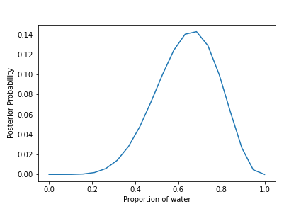

```python
f, ax = plt.subplots(figsize=(6,4))
ax.plot(p_grid,posterior);
ax.set_xlabel('Proportion of water');
ax.set_ylabel('Posterior Probability');
##plt.show();
# Note - the absurd number of semi colons is to suppress output lines in the RMD used to create this document.
# One at the end is enough for "normal" running of the code!
```

### **R**

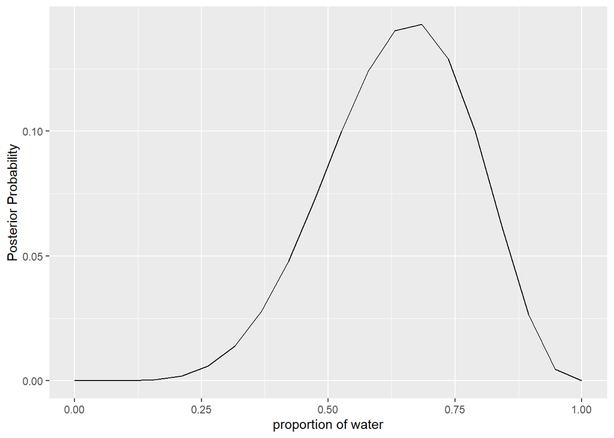

```r
# Converted to a tibble so GGplot can be used.
globe_toss <- tibble(p_grid, posterior)

ggplot2::ggplot(data = globe_toss, aes(x = p_grid, y = posterior ) ) +
  geom_line() +
  labs(x = "proportion of water", y = "Posterior Probability")
```

Running the experiment with a different prior changes the posterior.

The previous prior was 1; If this is changed so any values in the `p_grid` < 0.5 have a new prior of 0 what happens to the posterior?

## Change Prior

### **Python**

```python
prior2 = np.where(p_grid < 0.5, 0, 1)
prior2
```

```
## array([0, 0, 0, 0, 0, 0, 0, 0, 0, 0, 1, 1, 1, 1, 1, 1, 1, 1, 1, 1])
```

### **R**

```r
prior2 = ifelse(p_grid < 0.5, 0, 1)
prior2
```

```
##  [1] 0 0 0 0 0 0 0 0 0 0 1 1 1 1 1 1 1 1 1 1
```

## Calculate posterior

### **Python**

```python
# Compute the posterior
unstandardised_posterior2 = likelihood * prior2

# Standardise the posterior so that it sums to 1
posterior2 = unstandardised_posterior2 / np.sum(unstandardised_posterior2)
posterior2
```

```
## array([0.        , 0.        , 0.        , 0.        , 0.        ,
##        0.        , 0.        , 0.        , 0.        , 0.        ,
##        0.12043392, 0.14984676, 0.16920098, 0.17224045, 0.15548894,
##        0.12043392, 0.07483503, 0.03190104, 0.00561896, 0.        ])
```

### **R**

```r
# compute the posterior
unstandardise_posterior2 <- likelihood * prior2

# Standardise the posterior so it sums to 1

posterior2 <- unstandardise_posterior2 / sum(unstandardise_posterior2)
posterior2
```

```
##  [1] 0.000000000 0.000000000 0.000000000 0.000000000 0.000000000 0.000000000
##  [7] 0.000000000 0.000000000 0.000000000 0.000000000 0.120433917 0.149846759
## [13] 0.169200982 0.172240449 0.155488943 0.120433917 0.074835031 0.031901037
## [19] 0.005618965 0.000000000
```

## Plot

Plotting the posterior distribution gives a better sense of what it looks like. More points in a grid will give a smoother approximation of the posterior distribution.

### **Python**

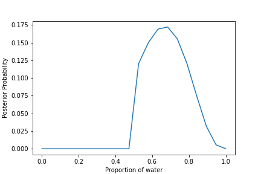

```python
f, ax = plt.subplots(figsize = (6,4))
ax.plot(p_grid,posterior2);
ax.set_xlabel('Proportion of water');
ax.set_ylabel('Posterior Probability');
plt.show();

# Note - the absurd number of semi colons is to suppress output lines in the RMD used to create this document
#One at the end is enough for "normal" running of the code!
```

### **R**

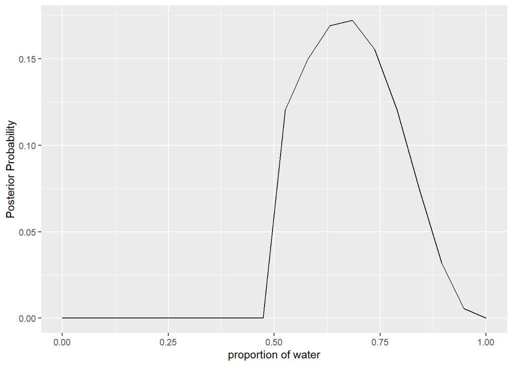

```r
# Converted to a tibble so GGplot can be used.
globe_toss2 <- tibble(p_grid, posterior2)

ggplot2::ggplot(data = globe_toss2, aes(x = p_grid, y = posterior2 ) ) +
  geom_line() +
  labs(x = "proportion of water", y = "Posterior Probability")
```

## Exercise

### **Question**

You are given some data reporting the sex of first born children in families. Male = 1, female = 0.

What is the probability of the 1st born child being male?

Use a grid approximation with 200 points.

Plot your results.

Python

```python
first_born = [0,1,0,1,0,1,1,1,0,0,1,1,1,1,1,0,0,1,1,1,0,0,1,1,
                1,0,1,1,1,0,1,1,1,0,1,0,0,1,1,1,1,0,0,1,0,1,1,1,
                1,1,1,1,1,1,1,1,1,1,1,1,1,0,1,1,0,1,1,0,1,1,1,0,
                0,0,0,0,0,1,0,0,0,1,1,0,0,1,0,0,1,1,0,0,0,1,1,1,
                0,0,0,0]
```

R

```r
first_born <- c(0,1,0,1,0,1,1,1,0,0,1,1,1,1,1,0,0,1,1,1,0,0,1,1,
                1,0,1,1,1,0,1,1,1,0,1,0,0,1,1,1,1,0,0,1,0,1,1,1,
                1,1,1,1,1,1,1,1,1,1,1,1,1,0,1,1,0,1,1,0,1,1,1,0,
                0,0,0,0,0,1,0,0,0,1,1,0,0,1,0,0,1,1,0,0,0,1,1,1,
                0,0,0,0)
```

### **Python Answer**

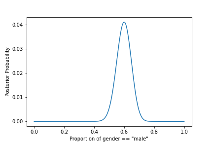

```python
# Data

first_born = [0,1,0,1,0,1,1,1,0,0,1,1,1,1,1,0,0,1,1,1,0,0,1,1,
                1,0,1,1,1,0,1,1,1,0,1,0,0,1,1,1,1,0,0,1,0,1,1,1,
                1,1,1,1,1,1,1,1,1,1,1,1,1,0,1,1,0,1,1,0,1,1,1,0,
                0,0,0,0,0,1,0,0,0,1,1,0,0,1,0,0,1,1,0,0,0,1,1,1,
                0,0,0,0]

# work out n (number of trails)
n = len(first_born)

# work out "successes" e.g 1 or "male" values.
k = first_born.count(1)


# Create the Grid
p_grid2 = np.linspace(start=0, stop=1, num=200)


# Define the prior as a constant value of 1
prior = np.repeat(1, repeats=200)

# Calculate the Likelihood using the binomial function
likelihood = binom.pmf(k= k , n= n, p=p_grid2)

# Compute the posterior
unstandardised_posterior = likelihood * prior

# Standardise the posterior so that it sums to 1
posterior = unstandardised_posterior / np.sum(unstandardised_posterior)

# Plot
f, ax = plt.subplots(figsize=(6,4))
ax.plot(p_grid2,posterior);
ax.set_xlabel('Proportion of gender == "male"');
ax.set_ylabel('Posterior Probability');
#plt.show();

# Note - the absurd number of semi colons is to suppress output lines in the RMD used to create this document
#One at the end is enough for "normal" running of the code!
```

### **R Answer**

[figure not shown]

```r
first_born <- c(0,1,0,1,0,1,1,1,0,0,1,1,1,1,1,0,0,1,1,1,0,0,1,1,
                1,0,1,1,1,0,1,1,1,0,1,0,0,1,1,1,1,0,0,1,0,1,1,1,
                1,1,1,1,1,1,1,1,1,1,1,1,1,0,1,1,0,1,1,0,1,1,1,0,
                0,0,0,0,0,1,0,0,0,1,1,0,0,1,0,0,1,1,0,0,0,1,1,1,
                0,0,0,0)


# work out n (number of trails)
n <- length(first_born)

# work out "successes" e.g 1 or "male" values.
successes <- length(first_born == 1)


# Create the Grid
p_grid2 <- seq(from = 0, to = 1, length.out = 20 ) # define grid

# Define the prior as a constant value of 1
prior <- rep(1, times = 200)

# Calculate the Likelihood using the binomial function
likelihood <- dbinom(x= successes, size= n, prob=p_grid)

# Compute the Posterior
unstandardised_posterior <- likelihood * prior

# Standardise the posterior so that it sums to 1
posterior <- unstandardise_posterior / sum(unstandardise_posterior)

# Converted to a tibble so GGplot can be used.
first_born_tb <- tibble(p_grid2, posterior)

ggplot2::ggplot(data = first_born_tb, aes(x = p_grid2, y = posterior ) ) +
  geom_line() +
  labs(x = "Proportion of gender == 'male'", y = "Posterior Probability")
```

# 10 Quardratic Aproximation

As the globe tossing model has only one parameter estimating that value is quite simple - even on a grid of 100 or even 1000 points. However with even just 2 parameters to estimate this increases to $100^2$ or $1000^2$ points; this can become computationally expensive. Quadratic approximation may be a more useful alternative in this case. Quadratic Approximation is also known as Laplace Approximation.

Quadratic approximation makes a normal or ‘Gaussian’ approximation to the posterior. This is computationally lightweight as a normal distribution is able to be defined with a mean and a standard deviation.

In quadratic approximation

1. The mean is derived from finding the maximum a posteriori (the mode or “peak” of the posterior distribution)
2. The standard deviation is more complicated. In simple terms the optimiser that finds the maximum a posteriori uses a transformation called a Hessian to find the peak of the distribution. Mathematically the inverse of a Hessian gives us the covariance of a Gaussian distribution.

### **Python**

```python
globe_model = pm.Model()
# W L W W W L W L W
data = np.array([1,0,1,1,1,0,1,0,1])

# Specify the model
with globe_model:
    p = pm.Uniform('p', lower = 0, upper = 1) # prior
    k = pm.Binomial('k', n = len(data), p = p, observed = data.sum()) # likelihood
```

In this model the prior $p$ is specified as belonging to a uniform distribution with the range of 0 to 1. As $p$ is the only thing to be estimated this is the only prior. The other parameters are observed data.

The likelihood function is given by the Binomial distribution.

- `n` is the number of trials in our data; found by getting the length of the trials.
- `p` is set to the prior variable defined earlier as there is no observations for this.
- `observed` is the number of 1’s in our data, achieved by summing the data.

The model can now be used

```python
mean = pm.find_MAP(model = globe_model)
mean['p']
```

```
## array(0.66666667)
```

The peak of the posterior distribution (the MAP estimate) is at 0.666. This can be used as the mean in the normal (quadratic) approximation of the full posterior distribution.

```python
# standard deviation is the square root of the inverse of the Hessian.
std_dev = np.sqrt(1/(pm.find_hessian(mean, vars = [p], model = globe_model)[0]))
std_dev
```

```
## array([0.15713484])
```

The estimate of the standard deviation of $p$ is around 0.16. Using the mean and the standard deviation of $p$ allows the specification of a normal curve that approximates the posterior distribution of $p$, the proportion of the surface of Earth that is water.

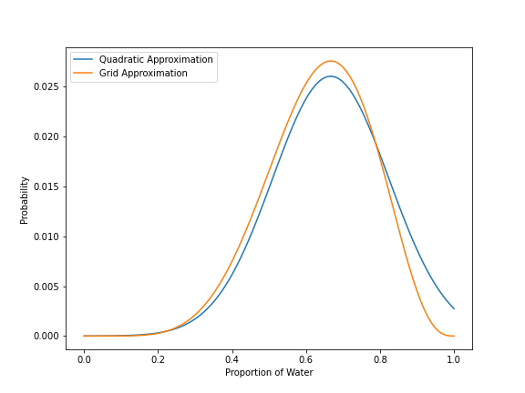

```python
f, ax = plt.subplots(figsize = (8,6))
x = np.linspace(0,1,100)
norm_pdf = norm.pdf(x, mean['p'], std_dev)
ax.plot(x, norm_pdf/sum(norm_pdf), label = "Quadratic Approximation")

# Grid Approximation on 100 gridpoints with flat (uniform) prior.
prior = np.repeat(1, 100)
likelihood = binom.pmf(6, 9, x)
# Compute the posterior
unstandardised_posterior = likelihood * prior
# Standardise the posterior so that it sums to 1
posterior = unstandardised_posterior/ np.sum(unstandardised_posterior)
ax.plot(x, posterior, label = 'Grid Approximation')
ax.legend()
ax.set_xlabel("Proportion of Water")
ax.set_ylabel('Probability')
plt.show();
```

There is a difference between the grid approximation and the quadratic approximation. This is because the quadratic approximation is not great with small numbers, like this instance. Given more data the quadratic will improve.

### **R**

```r
data <- c(1,0,1,1,1,0,1,0,1)

y <- sum(data == 1)
n <- length(data)

prior <- list(a = 1, b = 1)

posterior <- list(a = prior$a + y,  b = prior$b + n - y)
```

Here a function called `calc_posterior` has been created; which uses our priors and posteriors.

```r
calc_posterior <- function(par) {
  lprior <- dbeta(par, prior$a, prior$b, log = TRUE)
  lpost <- dbinom(y, size = n, prob = par, log = TRUE)
  - (lprior + lpost)
}
```

This is then applied using the optim function from the stats package; specifying a hessian.

```r
ret <- optim(0.5, fn = calc_posterior, hessian = TRUE, method = "Brent",
             lower = 0, upper = 1)
```

We can use this to find our MAP

```r
map_max <- ret$par
map_max
```

```
## [1] 0.6666667
```

The peak of the posterior distribution (the MAP estimate) or theta is at 0.666. This can be used as the mean in the normal (quadratic) approximation of the full posterior distribution.

```r
# standard deviation is the square root of the inverse of the Hessian.
std_dev <- sqrt(1/ret$hessian)
std_dev
```

```
##           [,1]
## [1,] 0.1571338
```

```r
theta_var <- 1 / drop(ret$hessian)
```

The estimate of the standard deviation of $p$ is around 0.16. Using the mean and the standard deviation of $p$ allows the specification of a normal curve that approximates the posterior distribution of $p$, the proportion of the surface of Earth that is water.

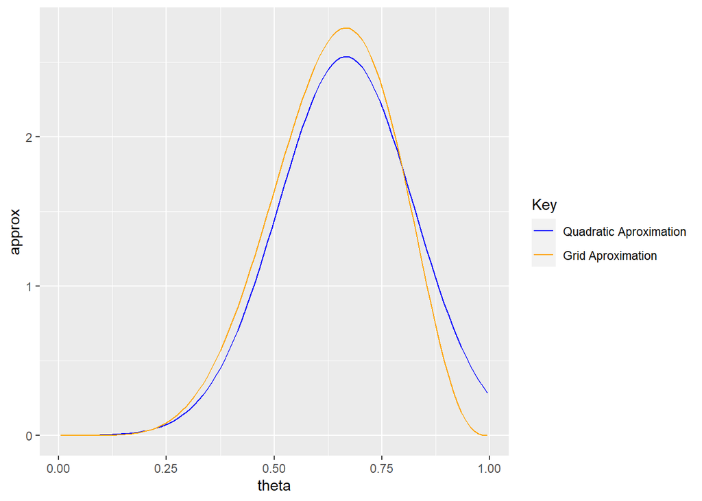

```r
tibble(
  theta = ppoints(100),
  approx = dnorm(theta, map_max, sqrt(theta_var)),
  actual = dbeta(theta, shape1 = posterior$a, shape2 = posterior$b)
) %>%
  ggplot2::ggplot(aes(x = theta)) +
  geom_line(aes(y = approx, color = "blue")) +
  geom_line(aes(y = actual, colour = "orange")) +
  scale_color_identity(name = "Key",
                          breaks = c("blue", "orange"),
                          labels = c("Quadratic Aproximation", "Grid Aproximation"),
                          guide = "legend")
```

There is a difference between the grid approximation and the quadratic approximation. This is because the quadratic approximation is not great with small numbers, like this instance. Given more data the quadratic will improve.

# 11 Markov Chain Monte Carlo (MCMC)

Unlike previous methods where the posterior distribution is calculated directly MCMC techniques draw a sample from the posterior; this gives a collection of parameter values where the frequencies of those values correspond with the posterior plausibilities.

### **Python**

```python
posterior_sample = pm.sample(model = globe_model, random_seed=99)
```

### **R**

```r
posterior_sample <- MCMCpack::MCbinomialbeta(y = sum(data), n = length(data), beta = 1,  mc = 1000, seed = 99)
```

MCMC samplers can be complicated, however this is a simple task and the defaults are often sufficient.

### **Python**

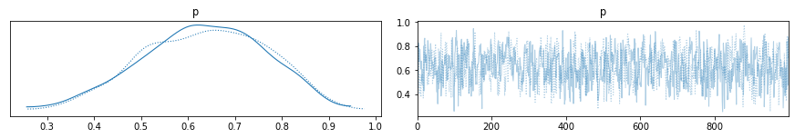

```python
pm.traceplot(posterior_sample);
```

### **R**

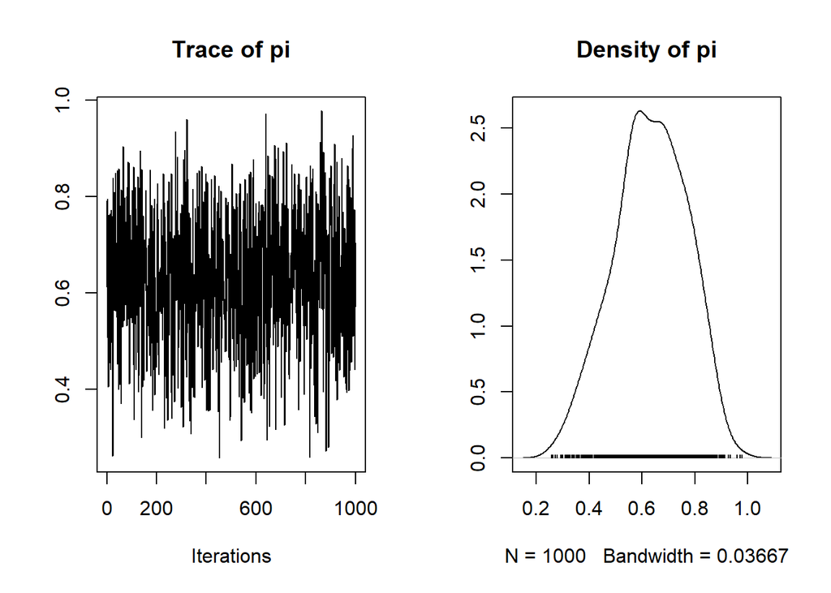

```r
plot(posterior_sample)
```

More aesthetically pleasing trace and density plots can be created using the packages `coda` which is loaded as a dependency of `MCMCpack`

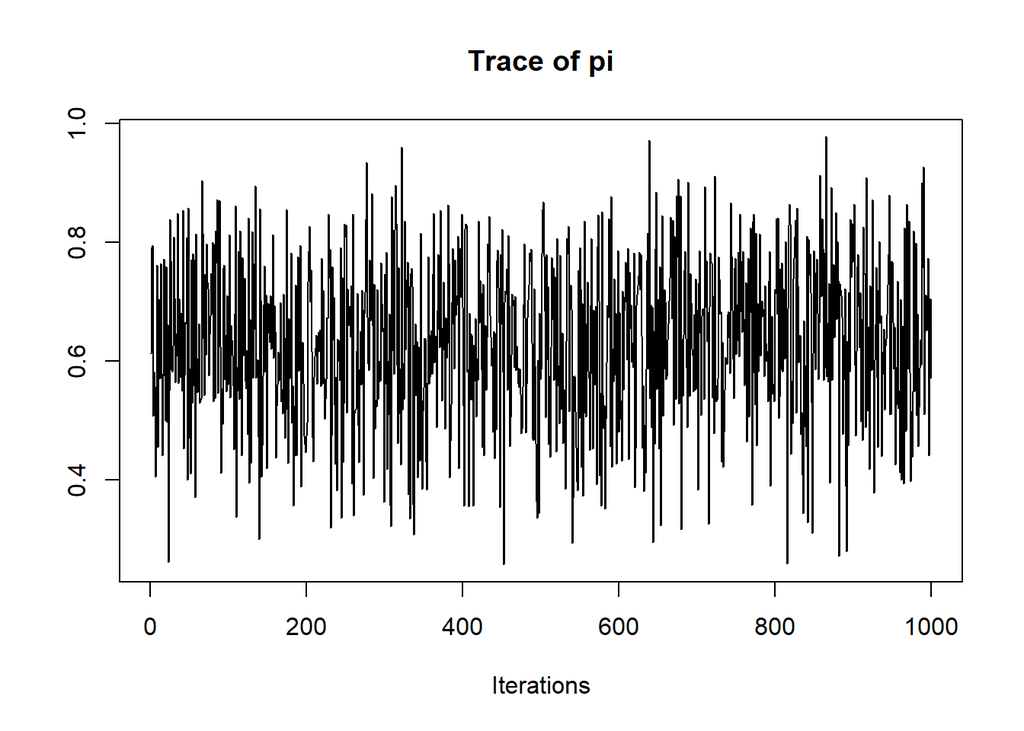

```r
coda::traceplot(posterior_sample)
```

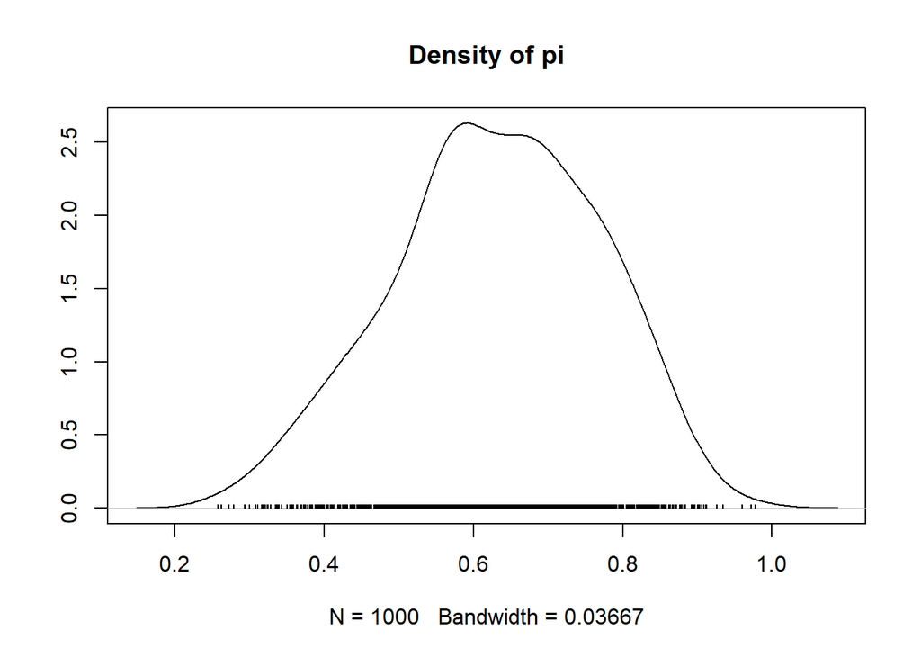

```r
coda::densplot(posterior_sample)
```

Or using the package `bayesplot`

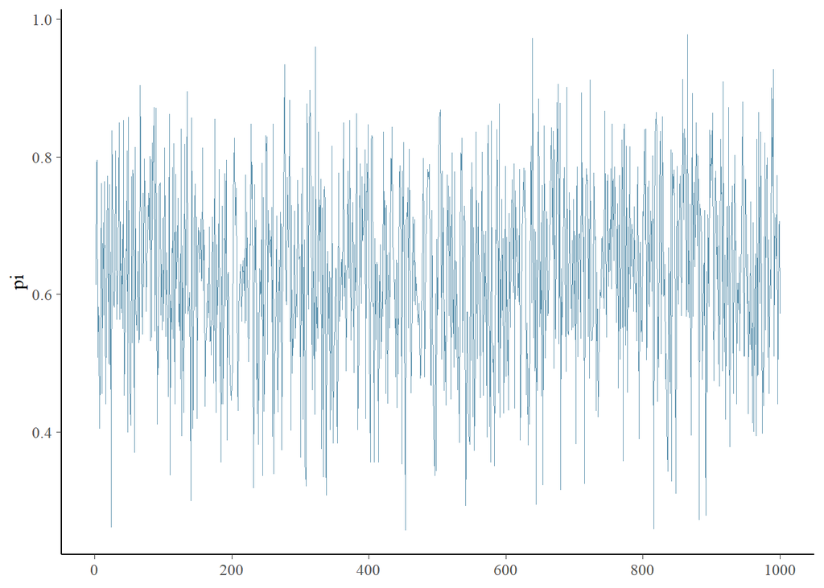

```r
bayesplot::mcmc_trace(posterior_sample)
```

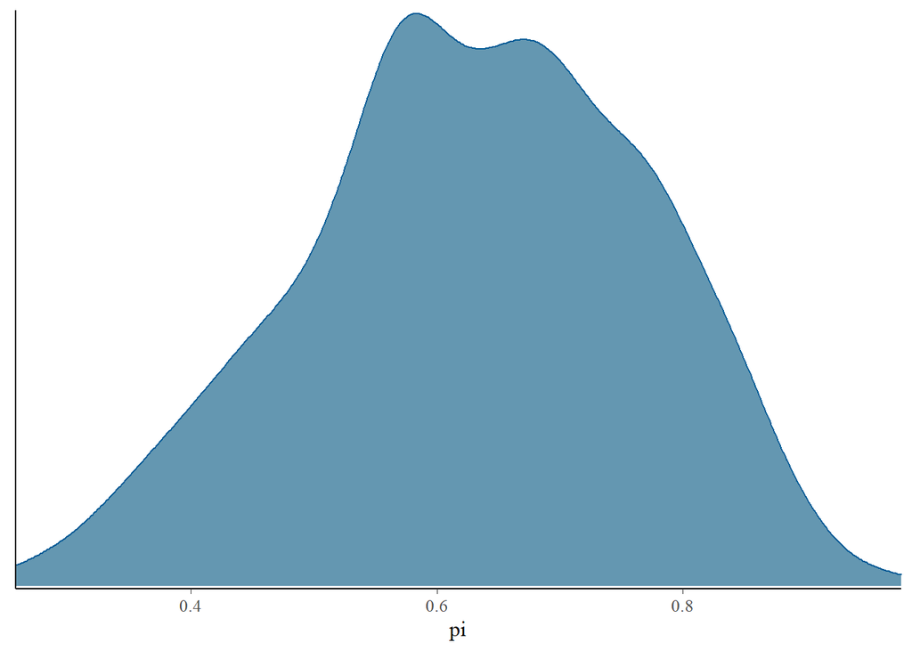

```r
bayesplot::mcmc_dens(posterior_sample)
```

This diagram is called a “traceplot” and gives a sense of if the MCMC process is a good one based on how well mixed the samples are.

The sampler has created samples from the posterior distribution of $p$ that are very similar to the other methods calculated previously.

# 12 Summarising Posterior Distributions

We can get summary statistics of the posterior.

Using MCMC allows us to look at some summary statistics of the posterior:

### **Python**

```python
pm.summary(posterior_sample)
```

[output not shown]

### **R**

```r
summary(posterior_sample)
```

```
##
## Iterations = 1:1000
## Thinning interval = 1
## Number of chains = 1
## Sample size per chain = 1000
##
## 1. Empirical mean and standard deviation for each variable,
##    plus standard error of the mean:
##
##           Mean             SD       Naive SE Time-series SE
##       0.630862       0.137717       0.004355       0.004355
##
## 2. Quantiles for each variable:
##
##   2.5%    25%    50%    75%  97.5%
## 0.3557 0.5408 0.6355 0.7332 0.8712
```

```r
quantile(posterior_sample, c(0.03, 0.97))
```

```
##        3%       97%
## 0.3579430 0.8637704
```

Using the sample allows for a number of questions to be answered. A selection of common questions are:

- How much of the posterior probability lies below a given parameter value?
- How much of a posterior probability lies between the two parameter values?
- Which parameter value marks the lower 5% of the posterior distribution?
- Which range of parameter values contains 90% of the posterior probability?
- Which parameter value has the highest posterior probability?

## How much of a posterior probability is less than 0.5?

This can be used to calculate the posterior probability that surface water makes up less than 50% of the Earth’s surface.

### **Python**

```python
posterior_sample_array = posterior_sample.get_values(p)

(posterior_sample_array < 0.5).sum()/len(posterior_sample_array)
```

```
## 0.1665
```

### **R**

```r
sum(posterior_sample <= 0.5) / length(posterior_sample)
```

```
## [1] 0.175
```

This shows that approximately 17% of the posterior probability is below 0.5. This is the relative frequency of samples that meet our criteria (< 0.5) out of the total number of samples.

## How much of a posterior probability lies between 0.5 and 0.75?

### **Python**

```python
((posterior_sample_array > 0.5) & (posterior_sample_array < 0.75)).sum() / len(posterior_sample_array)
```

```
## 0.628
```

### **R**

```r
sum((posterior_sample >= 0.5) & (posterior_sample <= 0.75)) / length(posterior_sample)
```

```
## [1] 0.605
```

Approximately 62% of the posterior probability lies within a proportion of 0.5 and 0.75

## What is the value that covers the lower 80% of the posterior distribution?

### **Python**

```python
np.percentile(posterior_sample_array, 80)
```

```
## 0.7521118289192498
```

### **R**

```r
quantile(posterior_sample, probs = 0.80)
```

```
##       80%
## 0.7591731
```

80% of the samples in the posterior distribution lay below the value $p$ = 0.75

## What are the values that cover the middle 80% of the posterior distribution

### **Python**

```python
np.percentile(posterior_sample_array, [10, 90])
```

```
## array([0.45732041, 0.80614929])
```

The middle 80% is the range from the 10th to the 90th percentile. This relates to a posterior probability from around 0.45 to 0.80.

### **R**

```r
quantile(posterior_sample, probs = c(0.1,0.9))
```

```
##       10%       90%
## 0.4406456 0.8099003
```

The middle 80% is the range from the 10th to the 90th percentile. This relates to a posterior probability from around 0.44 to 0.81. The numbers for the Python and R calculation differ slightly; this is due to slight differences in the sampling under the hood between the two languages.

## Highest Probability Density Interval

### **Python**

```python
pm.stats.hdi(posterior_sample_array)
```

```
## array([0.3845, 0.859])
```

The highest density interval is the minimum width Bayesian Credible Interval (BCI)

In this example that is between 0.38 and 0.85

### **R**

```r
HDInterval::hdi(posterior_sample)
```

```
##              pi
## lower 0.3557827
## upper 0.8712906
## attr(,"credMass")
## [1] 0.95
```

The highest density interval is the minimum width Bayesian Credible Interval (BCI)

## Mean and Median Point Estimates

### **Python**

```python
np.mean(posterior_sample_array)
np.median(posterior_sample_array)
```

```
## (0.63404908077911, 0.6381278200039779)
```

### **R**

```r
c(mean = mean(posterior_sample), median = median(posterior_sample))
```

```
##      mean    median
## 0.6308625 0.6354503
```

# 13 Bayesian Linear Regression Models

This section will explore Bayesian inference in simple linear regressions.

This section uses the `criminals` data. In 1902 a social scientist called W.R Macdonell published a paper `On Criminal Anthropometry and the Identification of Criminals` which contained tables of physical characteristic of 3,000 non habitual male criminals, all over 21 who were serving sentences in England and Wales. Macdonell expressed an interest in if a limited number of anthropocentric measurements could be used to identify criminals. It’s not clear from the paper if he believes these measurements can distinguish individual criminals or if that certain sets of measurements could identify criminality.

This data contains

- Height in cm
- Length of left middle finger in cm

As with all new datasets - looking at the summary information can be helpful.

### **Python**

```python
criminals.head(5)
```

```
##    finger_length  height
## 0           10.0  142.24
## 1           10.3  144.78
## 2            9.9  147.32
## 3           10.2  147.32
## 4           10.2  147.32
```

```python
criminals.describe()
```

```
##        finger_length       height
## count    3000.000000  3000.000000
## mean       11.547367   166.301420
## std         0.548714     6.496702
## min         9.500000   142.240000
## 25%        11.200000   162.560000
## 50%        11.500000   165.100000
## 75%        11.900000   170.180000
## max        13.500000   195.580000
```

### **R**

```r
head(criminals, n = 5)
```

```
## # A tibble: 5 x 2
##   finger_length height
##           <dbl>  <dbl>
## 1          10     142.
## 2          10.3   145.
## 3           9.9   147.
## 4          10.2   147.
## 5          10.2   147.
```

```r
summary(criminals)
```

```
##  finger_length       height
##  Min.   : 9.50   Min.   :142.2
##  1st Qu.:11.20   1st Qu.:162.6
##  Median :11.50   Median :165.1
##  Mean   :11.55   Mean   :166.3
##  3rd Qu.:11.90   3rd Qu.:170.2
##  Max.   :13.50   Max.   :195.6
```

Visualising this data can also be beneficial.

### **Python**

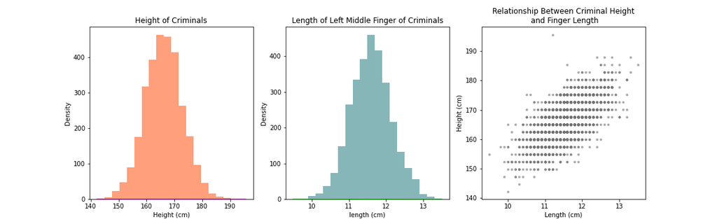

```python
f, (ax1, ax2, ax3) = plt.subplots(1,3, figsize = (16,5))

# Height
ax1.hist(criminals['height'], bins = 20, color = 'coral', alpha = 0.75);
xs = np.linspace(criminals['height'].min(), criminals['height'].max(),100);
norm_ys = norm.pdf(xs, loc = criminals['height'].mean(), scale = criminals['height'].std());
ax1.plot(xs, norm_ys, color = 'fuchsia', linewidth = 2);
ax1.set_title("Height of Criminals");
ax1.set_ylabel("Density");
ax1.set_xlabel('Height (cm)');


# Finger Length
ax2.hist(criminals['finger_length'], bins = 20, color = 'cadetblue', alpha = 0.75);
xs = np.linspace(criminals['finger_length'].min(),criminals['finger_length'].max(),100);
norm_ys = norm.pdf(xs, loc = criminals['finger_length'].mean(), scale = criminals['finger_length'].std());
ax2.plot(xs, norm_ys, color = 'lime', linewidth = 2);
ax2.set_title("Length of Left Middle Finger of Criminals");
ax2.set_ylabel("Density");
ax2.set_xlabel('length (cm)');

# Scatter
ax3.scatter(y = criminals['height'], x = criminals['finger_length'], marker='.', color = '0.45', alpha = 0.5 );
ax3.set_title("Relationship Between Criminal Height\n and Finger Length");
ax3.set_ylabel("Height (cm)");
ax3.set_xlabel("Length (cm)");
plt.show();
```

### **R**

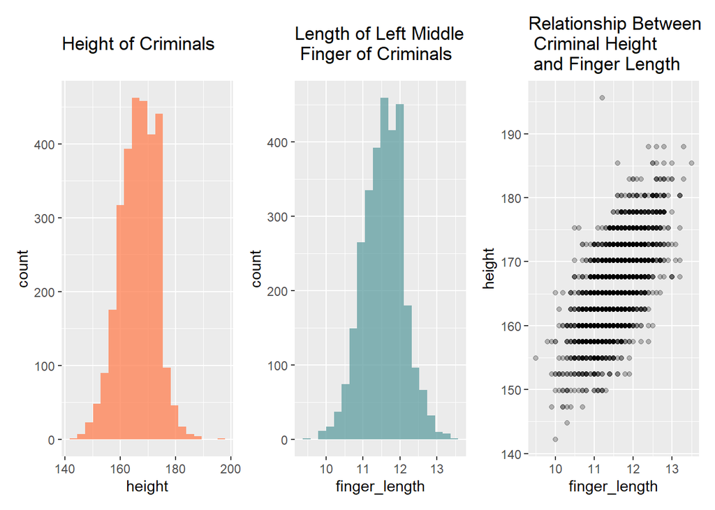

```r
plot_height <- ggplot2::ggplot(data = criminals) +
  geom_histogram(aes(x = height), bins = 20, fill = "coral", alpha = 0.75) +
  labs(title = "Height of Criminals")

plot_fingerlength <- ggplot2::ggplot(data = criminals) +
  geom_histogram(aes(x = finger_length), bins = 20, fill = "cadetblue", alpha = 0.75) +
  labs(title = "Length of Left Middle \n Finger of Criminals")

plot_scatter <- ggplot2::ggplot(data = criminals) +
  geom_point(aes(y = height, x = finger_length), alpha = 0.25) +
  labs(title = "Relationship Between \n Criminal Height\n and Finger Length")

plot_height + plot_fingerlength + plot_scatter  # This requires patchwork package to place plots side by side
```

## 13.1 Model Description.

- Outcome Variables - The data that we want to predict or explain with the model
- Outcome likelihood - The likelihood function that defines the plausibility of individual observations in the outcome data. (For linear regression this is always the normal(Gaussian) distribution)
- Explanatory Variables - The remaining data that we want to model to predict or explain the outcome
- Relationship Likelihood to Predictors - The explanatory variables are related to the outcome likelihood parameters
- Priors Specified - All parameters for the model have a prior set to explain the initial state of the model before seeing the data.

In mathematical notation this is:

$$\begin{aligned}
outcome_i \sim Normal(\mu_i, \sigma) \\
\mu_i = \alpha + \beta \times explanatory_i \\
\alpha \sim Normal(0,1) \\
\beta \sim Normal(0,1) \\
\sigma \sim Uniform(0,1)
\end{aligned}$$
The first line is the likelihood function for the outcome we are interested in. As this is a linear regression the assumption is the outcome is the realisation of a normal distribution with given mean ($\mu$) and standard deviation ($\sigma$).

The tilde ($/sim$) specifies that the outcome (prior) is random (stochastic). ALthough the prior is mapped to a distribution no single outcome can be known with any certainty. Instead the distribution identifies the different plausibility of values for the outcome or prior.

The linear model ($\alpha + \beta \times explanatory_i$) has two parameters to estimate and this the the equivalent of a conventional linear model.

- $\alpha$ - The expected (mean) value of the outcome when the explanatory variable is equal to 0. This is the intercept.
- $\beta$ - What is the change in the expected (mean) value of the outcome subject to a 1 unit change in the explanatory value. This is the slope or gradient.

This gives 3 priors to deal with; the model parameters $\alpha$ and $\beta$ and the standard deviation of outcome $\sigma$. Without any additional information a normal prior for $\alpha$ and $\beta$ with a reasonable mean for the data in question and an arbitrarily large standard deviation to allow the model some freedom in providing a good solution. The prior for $\sigma$ should always be > 0 as a negative standard deviation isn’t possible. A wide uniform prior starting at zero is a weak prior that allows the model some flexibility.

## 13.2 Applying the Model

The model specification for a Bayesian Linear Regression Model to predict criminal height as a linear function of finger length looks like this:

$$\begin{aligned}
height \sim Normal(\mu_i, \sigma) \\
\mu_i = \alpha + \beta \times finger\ length_i \\
\alpha \sim Normal(166,100) \\
\beta \sim Normal(0,10) \\
\sigma \sim Uniform(0,50)
\end{aligned}$$
The likelihood is Gaussian; the mean is dependent on finger length.

The prior for $\alpha$ is Gaussian and centred on the overall mean for criminal heights (166) but with a huge standard deviation that will effectively allow the parameter to settle over an appropriate value for $\alpha$ - conceptually the mean height of criminals when finger length is 0; although in practice this wouldn’t happen.

The prior for $\beta$ is conservative; as a Gaussian centred on 0 it implies that we are giving equal weight to the possibility of a positive or negative parameter values for $\beta$, either a positive or negative slope; however we could expect $\beta$ to be positive. As a $\beta$ of 0 suggests no relationship this is a conservative prior assumption. The large standard deviation is again permissive to allow the parameter to move easily to a meaningful value. As this model uses a lot of data the impact of this conservative prior is weak, but with less data a more informative prior may be more useful.

Finally the prior for $\sigma$ is flat with a large range, again allowing the model flexibility to move to achieve a good fit.

The models can be translated into code.

### **Python**

```python
criminals_model = pm.Model()

with criminals_model:
    # Priors
    alpha = pm.Normal('alpha', mu = 166, sd = 100)
    beta = pm.Normal('beta', mu = 0, sd = 10)
    sigma = pm.Uniform('sigma', lower = 0, upper = 50)

    # Linear Model
    mu = alpha + beta * criminals['finger_length']

    # Likelihood
    height = pm.Normal('height', mu = mu, sd = sigma, observed = criminals['height'])
```

Note - this will take a very long time to run on ONS Machines. This is due to the package m2w64-toolchain not being available and the sample size being large (3000 rows)

A version of the posterior is available as a pickle file in the cell below. It is recommended you load that rather than try and calculate this yourself.

```python
# Caution - will take hours to run, load pickle in cell below.
posterior = pm.sample(model=criminals_model, tune = 4500)
```

Load the posterior via pickle if you are unable to run the sampler (likely)

```python
import pickle
with open('../data/model.pickle', 'rb') as buff:
    data = pickle.load(buff)
criminals_model = data['model']
posterior = data['trace']
```

### **R**

Here the function `stan_glm()` from the `rstanarm` package is used. This is creating a generalised linear model.

While in the Python model we specified the priors, here the defaults work well.

```r
criminals_model <- rstanarm::stan_glm(formula = "height ~ finger_length",
                   data = criminals)
```

Now the model is created it can be used to explore the relationship between finger length and height. We can find the *maximum a posteriori* values for $\alpha$ and $\beta$ and plot the line within the data. This is effectively the mean line; the most plausible line drawn from the infinite possible lines that make up the posterior distribution of this model. This is very similar to the standard least squares fit.

### **Python**

Find the MAP

```python
criminals_map = pm.find_MAP(model = criminals_model)
print(f"model alpha: {criminals_map['alpha']}, model beta: {criminals_map['beta']}")
```

```
## model alpha: 76.70927324810782, model beta: 7.758674279162565
```

Plot

[output not shown]

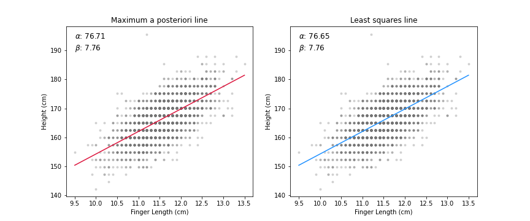

```python
f, (ax1, ax2) = plt.subplots(1, 2, figsize=(12,5))

# Maximum a posteriori
xs = np.linspace(criminals['finger_length'].min(),criminals['finger_length'].max(),2)
yhat_bayes = criminals_map['alpha'] + criminals_map['beta'] * xs
ax1.scatter(criminals['finger_length'], criminals['height'], marker='.', color = '0.45', alpha = 0.25)
ax1.plot(xs, yhat_bayes, color = 'crimson')
ax1.set_title("Maximum a posteriori line")
ax1.text(9.5, 194, r"$\alpha$: " + str(criminals_map['alpha'].round(2)), fontsize = 12)
ax1.text(9.5, 190, r"$\beta$: " + str(criminals_map['beta'].round(2)), fontsize = 12)
ax1.set_ylabel('Height (cm)')
ax1.set_xlabel('Finger Length (cm)')

# Least squares
params = np.polyfit(criminals['finger_length'], criminals['height'], deg = 1)

yhat_ols = params[1] + params[0] * xs
ax2.scatter(criminals['finger_length'], criminals['height'], marker='.', color = '0.45', alpha = 0.25)
ax2.plot(xs, yhat_ols, color = 'dodgerblue')
ax2.set_title("Least squares line")
ax2.text(9.5, 194, r"$\alpha$: " + str(params[1].round(2)), fontsize = 12)
ax2.text(9.5, 190, r"$\beta$: " + str(params[0].round(2)), fontsize = 12)
ax2.set_ylabel('Height (cm)')
ax2.set_xlabel('Finger Length (cm)');
plt.show()
```

### **R**

Find the MAP

```r
criminals_map <- bayestestR::map_estimate(criminals_model)
```

Plot

```r
# Maximum A Posteriori line
xs <- c(min(criminals$finger_length), max(criminals$finger_length))
yhat_bayes <- criminals_map$MAP_Estimate[1] + criminals_map$MAP_Estimate[2] * xs
yhat_bayes
```

```
## [1] 150.4373 181.4558
```

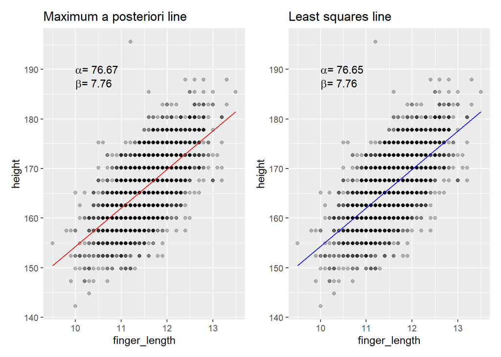

```r
# Plot
plot_map <- ggplot2::ggplot() +
  geom_point(aes(y = height, x = finger_length), data = criminals, alpha = 0.25) +
  geom_line(aes (x =xs,  y = yhat_bayes), color = "red") +
  labs(title = "Maximum a posteriori line") +
  annotate("text", x = 10, y = 190, label = expression(paste(alpha, "= 76.67")) , parse = TRUE, hjust = 0) +
  annotate("text", x = 10, y = 187, label = expression(paste(beta, "= 7.76")) , parse = TRUE, hjust = 0)

# OLS

ols_criminals <- lm(formula = "height ~ finger_length", data = criminals)

yhat_ols <- ols_criminals$coefficients[1] + ols_criminals$coefficients[2] * xs

# Plot
plot_ols <- ggplot2::ggplot() +
  geom_point(aes(y = height, x = finger_length),data = criminals, alpha = 0.25) +
  geom_line(aes(x = xs, y = yhat_ols), color = "blue") +
  labs(title = "Least squares line") +
  annotate("text", x = 10, y = 190, label = expression(paste(alpha, "= 76.65")) , parse = TRUE, hjust = 0) +
  annotate("text", x = 10, y = 187, label = expression(paste(beta, "= 7.76")) , parse = TRUE, hjust = 0)


plot_map + plot_ols  # This requires patchwork package to place plots side by side
```

However the maximum a posteriori line doesn’t show much of a sense of uncertainty or the range of plausible values that $\alpha$ or $\beta$ could take. As this is one of the reasons for choosing Bayesian modelling we will now explore this further.

We can inspect the traceplot and the summary for more information.

### **Python**

Note that these cells may take a while (at least several minutes) to run, even with loading in data this is quite a slow process on ONS machines.

Traceplot

```python
pm.traceplot(posterior);
```

[figure not shown]

Summary

```python
pm.summary(posterior)
```

| . | mean | sd | hdi_3% | hdi_97% | mcse_mean | mcse_sd | ess_bulk | ess_tail | r_hat |
| --- | --- | --- | --- | --- | --- | --- | --- | --- | --- |
| alpha | 77.799 | 1.924 | 74.083 | 81.122 | 0.87 | 0.659 | 5.0 | 69.0 | 1.32 |
| beta | 7.665 | 0.167 | 7.384 | 7.992 | 0.075 | 0.057 | 5.0 | 64.0 | 1.32 |
| sigma | 4.896 | 0.052 | 4.814 | 4.996 | 0.012 | 0.009 | 22.0 | 109.0 | 1.06 |

### **R**

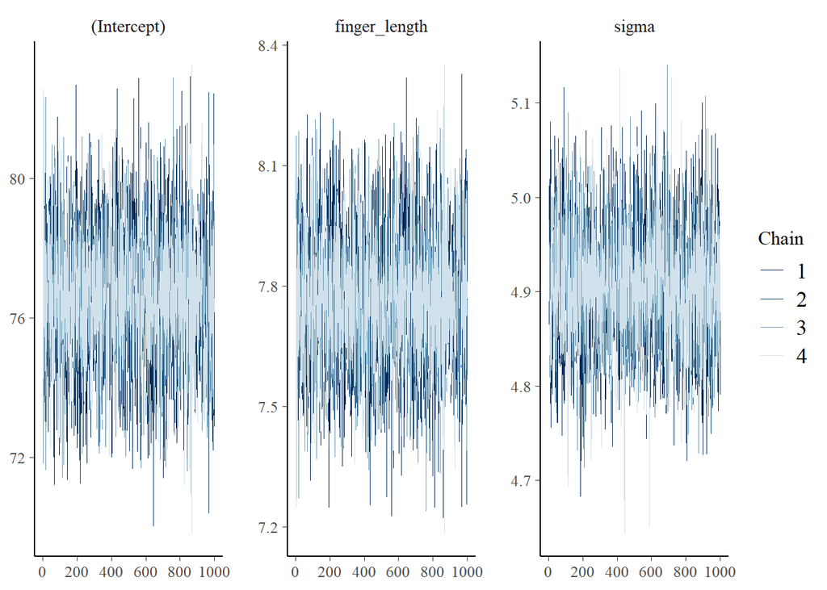

```r
bayesplot::mcmc_trace(criminals_model)
```

```r
summary(criminals_model)
```

```
##
## Model Info:
##  function:     stan_glm
##  family:       gaussian [identity]
##  formula:      "height ~ finger_length"
##  algorithm:    sampling
##  sample:       4000 (posterior sample size)
##  priors:       see help('prior_summary')
##  observations: 3000
##  predictors:   2
##
## Estimates:
##                 mean   sd   10%   50%   90%
## (Intercept)   76.6    1.9 74.1  76.7  79.1
## finger_length  7.8    0.2  7.6   7.8   8.0
## sigma          4.9    0.1  4.8   4.9   5.0
##
## Fit Diagnostics:
##            mean   sd    10%   50%   90%
## mean_PPD 166.3    0.1 166.1 166.3 166.5
##
## The mean_ppd is the sample average posterior predictive distribution of the outcome variable (for details see help('summary.stanreg')).
##
## MCMC diagnostics
##               mcse Rhat n_eff
## (Intercept)   0.0  1.0  3925
## finger_length 0.0  1.0  3960
## sigma         0.0  1.0  3599
## mean_PPD      0.0  1.0  3817
## log-posterior 0.0  1.0  1871
##
## For each parameter, mcse is Monte Carlo standard error, n_eff is a crude measure of effective sample size, and Rhat is the potential scale reduction factor on split chains (at convergence Rhat=1).
```

## 13.3 Uncertainty

The posterior effectively contains a lot of lines given the $\alpha$ and $\beta$ estimates. The MAP is the most plausible of these lines, but the variation in the sample of lines gives a sense of the uncertainty in the estimate of the “mean” line.

This can be seen in the chart below that plots some examples of lines in the posterior.

### **Python**

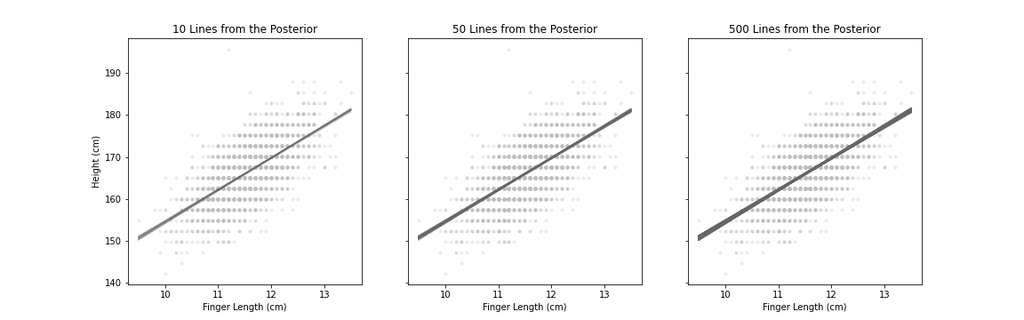

```python
# Plots
f, (ax1, ax2, ax3) = plt.subplots(1,3, figsize = (16, 5), sharex = True, sharey = True)

# x values for lines
xs = np.array([criminals['finger_length'].min(), criminals['finger_length'].max()]).reshape((-1,1))

# ax1 - ten random lines
rand_10 = np.random.randint(0,1000,10)
ten_lines = posterior[alpha][rand_10] + posterior[beta][rand_10] * xs
ax1.plot(xs, ten_lines, color = '0.4', alpha = 0.33)
ax1.scatter(criminals['finger_length'], criminals['height'], marker='.', color = '0.75', alpha = 0.25)
ax1.set_ylabel('Height (cm)')
ax1.set_xlabel('Finger Length (cm)')
ax1.set_title("10 Lines from the Posterior")

# ax2 - fifty random lines
rand_50 = np.random.randint(0,1000,50)
fifty_lines = posterior[alpha][rand_50] + posterior[beta][rand_50] * xs
ax2.plot(xs, fifty_lines, color = '0.4', alpha = 0.2)
ax2.scatter(criminals['finger_length'], criminals['height'], marker='.', color = '0.75', alpha = 0.25)
ax2.set_xlabel('Finger Length (cm)')
ax2.set_title("50 Lines from the Posterior")

# ax2 - five hundred random lines
rand_500 = np.random.randint(0,1000,500)
fivehundred_lines = posterior[alpha][rand_500] + posterior[beta][rand_500] * xs
ax3.plot(xs, fivehundred_lines, color = '0.4', alpha = 0.1)
ax3.scatter(criminals['finger_length'], criminals['height'], marker='.', color = '0.75', alpha = 0.25)
ax3.set_xlabel('Finger Length (cm)')
ax3.set_title("500 Lines from the Posterior");
plt.show()
```

### **R**

```r
# This may take about a minute to run.
ten_lines <- criminals %>%
  tidybayes::add_fitted_draws(criminals_model, n = 10) %>%  # Selects only n draws from the posterior
  ggplot(aes(x = finger_length, y= height)) +
  tidybayes::stat_lineribbon(aes(y = .value), .width = seq(0, 1, 0.1), alpha = 1/4, color = "red") +
  geom_point(data = criminals)+
  labs(title = "10 Lines from the Posterior")+
  scale_fill_brewer(guide = "none")
```

```
## Instead of posterior_linpred(..., transform=TRUE) please call posterior_epred(), which provides equivalent functionality.
```

```r
fifty_lines <- criminals %>%
  tidybayes::add_fitted_draws(criminals_model, n = 50) %>%
  ggplot(aes(x = finger_length, y= height)) +
  tidybayes::stat_lineribbon(aes(y = .value), .width = seq(0, 1, 0.1), alpha = 1/4, color = "red") +
  geom_point(data = criminals) +
  labs(title = "50 Lines from the Posterior") +
  scale_fill_brewer(guide = "none")
```

```
## Instead of posterior_linpred(..., transform=TRUE) please call posterior_epred(), which provides equivalent functionality.
```

```r
five_hundred_lines <- criminals %>%
  tidybayes::add_fitted_draws(criminals_model, n = 500) %>%
  ggplot(aes(x = finger_length, y= height)) +
  tidybayes::stat_lineribbon(aes(y = .value), .width = seq(0, 1, 0.1), alpha = 1/4, color = "red") +
  geom_point(data = criminals) +
  labs(title = "500 Lines from the Posterior") +
  scale_fill_brewer(guide = "none")
```

```
## Instead of posterior_linpred(..., transform=TRUE) please call posterior_epred(), which provides equivalent functionality.
```

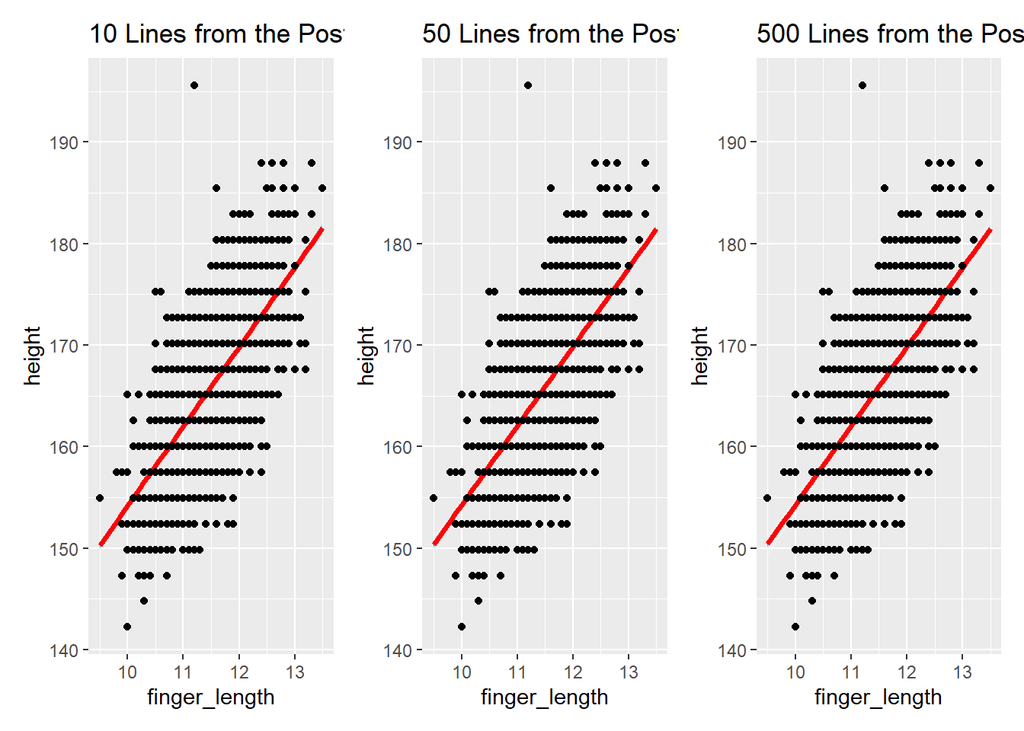

```r
ten_lines + fifty_lines + five_hundred_lines # This requires patchwork package to place plots side by side
```

Plotting these lines demonstrated the variation in estimates for the $\alpha$ and $\beta$ parameters.

## 13.4 Credible Intervals

### **Python**

Rather than plotting sampled lines in reality a Bayesian credible interval would be used. Before doing this it can be helpful to look at the distribution of mean estimates for given finger length.

```python
finger_length = 10.5 # cm

# means from posterior
mean_at_10_5 = posterior[alpha] + posterior[beta] * finger_length

# Plot the density curve for the posterior means.
f, ax = plt.subplots(figsize = (6,5))

xs = np.linspace(mean_at_10_5.min() - 1, mean_at_10_5.max() + 1, 100)
densities = gaussian_kde(mean_at_10_5)(xs)
ax.plot(xs, densities)
ax.set_xlabel("Height (cm)")
ax.set_ylabel("Density")
ax.set_title("Posterior Mean Height at finger length = 10.5cm")
plt.show();
```

[figure not shown]

This shows the approximation of the posterior distribution of mean height of criminals when their finger length is 10.5cm. This gives the relative plausibility of different values for mean height.

We can also compute the highest density interval for this distribution

```python
# hdi for finger length = 10.5
pm.hdi(mean_at_10_5)
```

```
## array([157.95163711, 158.65311572])
```

This uncertainty around the mean line can be expressed by extending the process to the full domain of the data.

```python
finger_lengths = np.arange(criminals['finger_length'].min(), criminals['finger_length'].max()+0.5, 0.5)
mu_predictions = np.array([posterior[alpha] + posterior[beta] * fl for fl in finger_lengths])
mu_mean = mu_predictions.mean(1)
mu_hdi = pm.hdi(mu_predictions.T)
```

[figure not shown]

### **R**

Rather than plotting sampled lines in reality a Bayesian credible interval would be used. Before doing this it can be helpful to look at the distribution of mean estimates for given finger length.

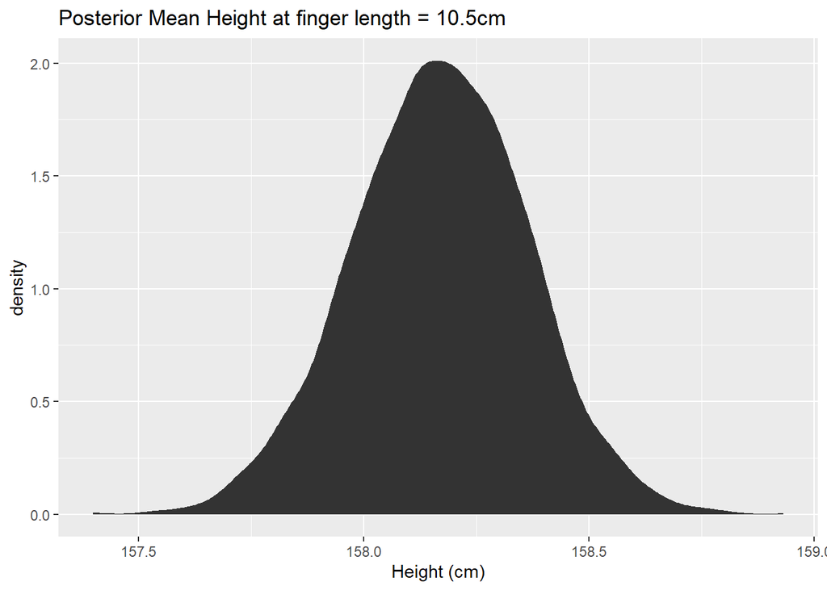

```r
posterior <- as.data.frame(criminals_model)
names(posterior)[1] <- "intercept"


finger_length <- 10.5 #cm

# means from posterior

mean_at_10_5 <- posterior$intercept + posterior$finger_length * finger_length

ggplot2::ggplot() +
  stat_density(aes(mean_at_10_5)) +
  labs(title = "Posterior Mean Height at finger length = 10.5cm", x = "Height (cm)")
```

This shows the approximation of the posterior distribution of mean height of criminals when their finger length is 10.5cm. This gives the relative plausibility of different values for mean height.

We can also compute the highest density interval for this distribution

```r
HDInterval::hdi(mean_at_10_5)
```

```
##    lower    upper
## 157.7884 158.5528
## attr(,"credMass")
## [1] 0.95
```

## 13.5 Prediction Interval

### **Python**

```python
finger_lengths1 = np.arange(criminals['finger_length'].min(), criminals['finger_length'].max()+0.1, 0.1)

# Generate heights from the posterior distribution
post_samples = []
for _ in range(1000):
    i = np.random.randint(len(posterior))
    mu_pred = posterior[alpha][i] + posterior[beta][i] * finger_lengths1
    post_samples.append(np.random.normal(mu_pred, posterior[sigma][i]))
post_samples = np.array(post_samples)

# get interval for generated heights
post_samples_hdi = pm.hdi(post_samples))
```

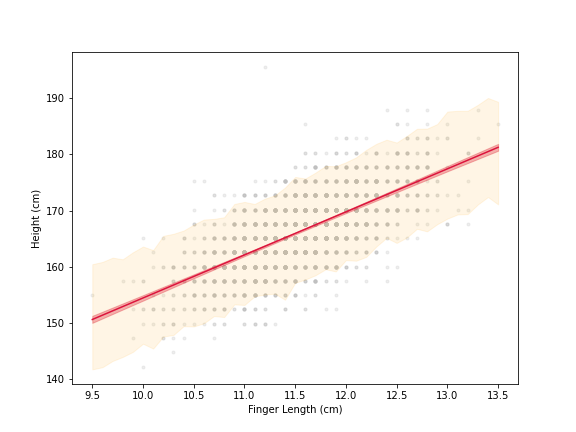

```python
f, ax = plt.subplots(figsize = (8,6))
ax.scatter(criminals['finger_length'], criminals['height'], marker='.', color = '0.75', alpha = 0.25)
ax.plot(finger_lengths, mu_mean, color = 'crimson')
ax.fill_between(finger_lengths, mu_hdi[:,0], mu_hdi[:,1], color = 'crimson', alpha = 0.33)
ax.fill_between(finger_lengths1, post_samples_hdi[:,0], post_samples_hdi[:,1], color = 'orange', alpha = 0.1)
ax.set_ylabel('Height (cm)')
ax.set_xlabel('Finger Length (cm)');
plt.show();
```

### **R**

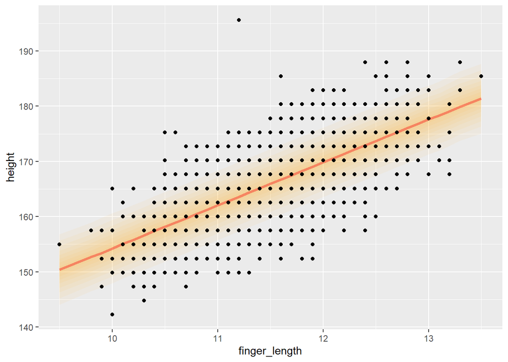

```r
prediction_interval <- criminals %>%
  tidybayes::add_predicted_draws(criminals_model) %>%
  ggplot(aes(x = finger_length, y= height)) +
  tidybayes::stat_lineribbon(aes(y = .prediction), .width = seq(0, 0.85, 0.1) , color = "red", fill = "orange", alpha = 1/20) +
  geom_point(data = criminals) +
  scale_fill_brewer(guide = "none")

prediction_interval
```

# 14 Summary

The topic of Bayesian Data Analysis is much much larger than can be covered within this course. For example this is a simple linear model - this could be expanded to a multivariate linear model if more explanatory values became available. You may like to think about how the model would change, and what that would mean for the inclusion of priors.

There is a list of references at the bottom of this course; but a strong recommendation throughout the research for this course has been McElreath R. 2016. **Statistical Rethinking: A Bayesian Course with Examples in R and Stan. CRC Press.**

# 15 References / Acknowledgements

The Analytical Function Learning Team for all of their help in getting all of the elements of this course to work so seamlessly.

Laurie Baker from the Data Science Campus - the segment on Bayesian Statistics as part of the Statistics for Data Science Python course has been a large influence on this course.

Pragya Paudyal, Aidan Metcalfe and James Cranston for their reviews and feedback.

[“Introduction to Bayesian Data Analysis” by Rasmus Bååth](https://www.youtube.com/watch?v=3OJEae7Qb_o)

[“Introduction to Bayesian Data Analysis” from “Analytical Paleobiology”, Peter D Smits, 2019-05-23](https://psmits.github.io/paleo_book/introduction-to-bayesian-data-analysis.html)

[“Alan Turing and Enigmatic Statistics”, Kanti V. Mardia and S. Barry Cooper, 2012-12](http://www.mathcomp.leeds.ac.uk/turing2012/Images/Turing_Statistics.pdf)

[“The signal and the noise: Nate Silver, Bayesian methods and higher education” Graeme Wise 2019-10-14 (PDF)](https://wonkhe.com/blogs/the-signal-and-the-noise-nate-silver-bayesian-methods-and-higher-education/)

[“What is Bayesian Analysis” STATA](https://www.stata.com/features/overview/bayesian-intro/#:~:text=Bayesian%20analysis%20is%20a%20statistical,between%2060%20and%2070%20inches%3F)

[“Updating: A Set of Bayesian Notes” Jeffery B Arnold, N.D](https://jrnold.github.io/bayesian_notes/bayesian-computation.html)

“Bayesian vs. Frequentist A/B Testing: What’s the Difference?” Alex Birkett 2020-01-18

[“Plotting MCMC draws using the bayesplot package”, Jonah Gabry, 2021-06-13](https://cran.r-project.org/web/packages/bayesplot/vignettes/plotting-mcmc-draws.html)

[“Extracting and visualizing tidy draws from rstanarm models” Matthew Kay, 2020-10-31](http://mjskay.github.io/tidybayes/articles/tidy-rstanarm.html)